# Renewable energy generator forecast

# 1. About the research

The hourly data collected electricity production of solar and wind speed generations was from Electronics Testing Center, Taiwan. Data from solar generator included DOWNWARD SHORT WAVE FLUX AT GROUND SURFACE(SWDOWN) and electricity production (PAC), and data from wind drive generator included 10 meter high of wind speed(WS10m), 65 meters high of wind speed (WS65m) and electricity production(PAC). There are five solar generation observations and two wind speed generations. This research visualized the insight of collected data and provided a deep learning model-LSTM to predict electricity production.

# 2. Data preparation for solar generator

Load the library all we need in this study first.

```r
library(lubridate)
```

```r
library(dygraphs)
library(ggplot2)
library(caret)
library(corrplot)
library(Metrics)
library(reshape2)
library(dplyr)
library(xts)
```

### 2.1 loading data

Five observed sites near the solar generators. Each of the sites recorded multiple information, and the most important variable is SWDOWN and PAC. We combined all the sites to a big data frame.

```r
chunghwa <- read.csv("C:/Users/Christine Liou/Documents/ETC/Data_1105/14.csv")
chunghwa$location <- "chunghwa"
dreamhouse <- read.csv("C:/Users/Christine Liou/Documents/ETC/Data_1105/19.csv")
dreamhouse$location <- "dreamhouse"
futurehouse <- read.csv("C:/Users/Christine Liou/Documents/ETC/Data_1105/18.csv")
futurehouse$location <- "futurehouse"
xinglongmarket <- read.csv("C:/Users/Christine Liou/Documents/ETC/Data_1105/39.csv")
xinglongmarket$location <- "xinglongmarket"
nuclearresearch <- read.csv("C:/Users/Christine Liou/Documents/ETC/Data_1105/40.csv")
nuclearresearch$location <- "nuclearresearch"
cbso <- rbind(chunghwa,dreamhouse,futurehouse,xinglongmarket,nuclearresearch)
rm(chunghwa,dreamhouse,futurehouse,xinglongmarket,nuclearresearch)

names(cbso)
```

```
##  [1] "SESSIONS"      "RANK"          "MYTIME"        "MYHOUR"
##  [5] "INITIAL_DATE"  "FCST"          "STNNO"         "FCST_DATETIME"
##  [9] "WS10M"         "WS65M"         "SWDOWN"        "USER_ID"
## [13] "INITIAL_TIME"  "EQUIPMENT_ID"  "T2"            "SHUM2"
## [17] "RAIN"          "PAC"           "VAC"           "IAC"
## [21] "EAC"           "location"
```

```r
names(cbso)[c(1:2,4:8,12:17)]
```

```
##  [1] "SESSIONS"      "RANK"          "MYHOUR"        "INITIAL_DATE"
##  [5] "FCST"          "STNNO"         "FCST_DATETIME" "USER_ID"
##  [9] "INITIAL_TIME"  "EQUIPMENT_ID"  "T2"            "SHUM2"
## [13] "RAIN"
```

```r
cbso <- cbso[,-c(1:2,4:8,12:17)]
summary(cbso)
```

```
##            MYTIME         WS10M              WS65M
##  2018/09/01 00:   5   Min.   :   0.043   Min.   :-999.0000
##  2018/09/01 01:   5   1st Qu.:   1.232   1st Qu.:   1.7948
##  2018/09/01 02:   5   Median :   2.197   Median :   3.0540
##  2018/09/01 03:   5   Mean   :   5.789   Mean   :   0.7302
##  2018/09/01 04:   5   3rd Qu.:   3.125   3rd Qu.:   4.2880
##  2018/09/01 05:   5   Max.   :1412.799   Max.   :  10.3460
##  (Other)      :6418
##      SWDOWN            PAC                VAC             IAC
##  Min.   :-999.0   Min.   :    0.00   Min.   :191.1   Min.   :  0.000
##  1st Qu.:   0.0   1st Qu.:    0.00   1st Qu.:221.2   1st Qu.:  0.400
##  Median :   0.0   Median :   53.33   Median :226.6   Median :  0.825
##  Mean   : 165.5   Mean   : 4779.09   Mean   :274.1   Mean   : 12.608
##  3rd Qu.: 253.4   3rd Qu.: 5401.49   3rd Qu.:230.9   3rd Qu.: 13.963
##  Max.   : 988.9   Max.   :48605.86   Max.   :447.6   Max.   :126.870
##
##       EAC          location
##  Min.   : 5317   Length:6448
##  1st Qu.:17941   Class :character
##  Median :32655   Mode  :character
##  Mean   :29537
##  3rd Qu.:37748
##  Max.   :49195
##
```

### 2.2 Transform the data to time series

Shift the data frame to be time series format.

```r
head(cbso$MYTIME)
```

```
## [1] 2018/09/01 00 2018/09/01 01 2018/09/01 02 2018/09/01 03 2018/09/01 04
## [6] 2018/09/01 05
## 1503 Levels: 2018/09/01 00 2018/09/01 01 2018/09/01 02 ... 2018/11/05 10
```

```r
date <- substr(cbso$MYTIME, 1,10)
time <- paste(substr(cbso$MYTIME,12, 13),":00:00",sep = "")
cbso$MYTIME <- as.POSIXct(paste(date,time, sep = " "))

cbso$location <- factor(cbso$location)

summary(cbso)
```

```
##      MYTIME                        WS10M              WS65M
##  Min.   :2018-09-01 00:00:00   Min.   :   0.043   Min.   :-999.0000
##  1st Qu.:2018-09-15 11:00:00   1st Qu.:   1.232   1st Qu.:   1.7948
##  Median :2018-10-01 18:00:00   Median :   2.197   Median :   3.0540
##  Mean   :2018-10-02 02:40:59   Mean   :   5.789   Mean   :   0.7302
##  3rd Qu.:2018-10-18 00:00:00   3rd Qu.:   3.125   3rd Qu.:   4.2880
##  Max.   :2018-11-05 10:00:00   Max.   :1412.799   Max.   :  10.3460
##      SWDOWN            PAC                VAC             IAC
##  Min.   :-999.0   Min.   :    0.00   Min.   :191.1   Min.   :  0.000
##  1st Qu.:   0.0   1st Qu.:    0.00   1st Qu.:221.2   1st Qu.:  0.400
##  Median :   0.0   Median :   53.33   Median :226.6   Median :  0.825
##  Mean   : 165.5   Mean   : 4779.09   Mean   :274.1   Mean   : 12.608
##  3rd Qu.: 253.4   3rd Qu.: 5401.49   3rd Qu.:230.9   3rd Qu.: 13.963
##  Max.   : 988.9   Max.   :48605.86   Max.   :447.6   Max.   :126.870
##       EAC                   location
##  Min.   : 5317   chunghwa       :1503
##  1st Qu.:17941   dreamhouse     :1503
##  Median :32655   futurehouse    :1503
##  Mean   :29537   nuclearresearch: 436
##  3rd Qu.:37748   xinglongmarket :1503
##  Max.   :49195
```

### 2.3 Remove missing data

The missing data were recorded in “-999”, therefore, we removed all the data showed “-999”.

```r
table(cbso$WS65M=="-999")
```

```
##
## FALSE  TRUE
##  6432    16
```

```r
cbso <- subset(cbso,WS65M!="-999")
summary(cbso)
```

```
##      MYTIME                        WS10M           WS65M
##  Min.   :2018-09-01 00:00:00   Min.   :0.043   Min.   : 0.086
##  1st Qu.:2018-09-15 10:00:00   1st Qu.:1.229   1st Qu.: 1.803
##  Median :2018-10-01 16:00:00   Median :2.192   Median : 3.058
##  Mean   :2018-10-02 01:20:40   Mean   :2.289   Mean   : 3.217
##  3rd Qu.:2018-10-17 22:00:00   3rd Qu.:3.119   3rd Qu.: 4.290
##  Max.   :2018-11-05 10:00:00   Max.   :9.142   Max.   :10.346
##      SWDOWN           PAC             VAC             IAC
##  Min.   :  0.0   Min.   :    0   Min.   :191.1   Min.   :  0.00
##  1st Qu.:  0.0   1st Qu.:    0   1st Qu.:221.2   1st Qu.:  0.40
##  Median :  0.0   Median :   50   Median :226.6   Median :  0.81
##  Mean   :168.4   Mean   : 4784   Mean   :274.1   Mean   : 12.62
##  3rd Qu.:254.2   3rd Qu.: 5408   3rd Qu.:230.9   3rd Qu.: 13.97
##  Max.   :988.9   Max.   :48606   Max.   :447.6   Max.   :126.87
##       EAC                   location
##  Min.   : 5317   chunghwa       :1499
##  1st Qu.:17929   dreamhouse     :1499
##  Median :32651   futurehouse    :1499
##  Mean   :29523   nuclearresearch: 436
##  3rd Qu.:37696   xinglongmarket :1499
##  Max.   :49195
```

### 2.4 Standardize the data

Standardized the numeriacal data.

```r
cbso_sc <- cbso[,c(2:5)]
cbso_sc <- scale(cbso_sc)
cbso_z <- as.data.frame(cbso_sc)
cbso_z <- cbind(cbso$MYTIME,cbso$location,cbso_z)
colnames(cbso_z) <- c("mytime","location","ws10m","ws65m","swdown","pac")
summary(cbso_z)
```

```
##      mytime                               location        ws10m
##  Min.   :2018-09-01 00:00:00   chunghwa       :1499   Min.   :-1.70944
##  1st Qu.:2018-09-15 10:00:00   dreamhouse     :1499   1st Qu.:-0.80698
##  Median :2018-10-01 16:00:00   futurehouse    :1499   Median :-0.07387
##  Mean   :2018-10-02 01:20:40   nuclearresearch: 436   Mean   : 0.00000
##  3rd Qu.:2018-10-17 22:00:00   xinglongmarket :1499   3rd Qu.: 0.63185
##  Max.   :2018-11-05 10:00:00                          Max.   : 5.21567
##      ws65m              swdown             pac
##  Min.   :-1.77558   Min.   :-0.6335   Min.   :-0.55077
##  1st Qu.:-0.80190   1st Qu.:-0.6335   1st Qu.:-0.55077
##  Median :-0.09021   Median :-0.6335   Median :-0.54502
##  Mean   : 0.00000   Mean   : 0.0000   Mean   : 0.00000
##  3rd Qu.: 0.60872   3rd Qu.: 0.3228   3rd Qu.: 0.07185
##  Max.   : 4.04270   Max.   : 3.0864   Max.   : 5.04569
```

# 3. Data visulation for solar generator

Preparing the data frame to draw prictures.

```r
cbso_sc <- cbso_z[,-2]
lcbso_sc <- melt(cbso_sc, id.vars='mytime', variable.name = "variable")
lcbso_sc$month <- factor(month(lcbso_sc$mytime))
lcbso_sc$day <- factor(day(lcbso_sc$mytime))
lcbso_sc$hour <- factor(hour(lcbso_sc$mytime))

DF_hour <- aggregate(value ~ hour*variable, data = lcbso_sc, FUN = mean)
DF_month <- aggregate(value ~ month*variable, data = lcbso_sc, FUN = mean)
day <- subset(DF_hour,DF_hour$hour %in% c(6:18))
night <- subset(DF_hour,DF_hour$hour %in% c(0:5,19:23))
```

### 3.1 All solar data for different time range

As the picture shows below, SWDOWN and PAC have the similar path during one day. These two variables rise when the sunrise, and decline to zero after the sunset.

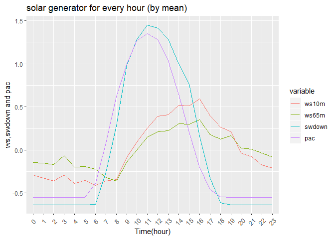

```r
mytheme <- theme_grey(base_family="STKaiti")
ggplot(data = DF_hour, mapping = aes(x = hour, y = value, color = variable, group = variable)) + geom_line()  + mytheme + theme(axis.text.x=element_text(angle=45, vjust=0.5)) + labs(x = "Time(hour)") + labs(y = "ws,swdown and pac") + ggtitle("solar generator for every hour (by mean)")
```

Despite there are only three month of data, we can still find out that SWDOWN and PAC data in Sep to Nov go down smoothly, because of the shorter day light in winter.

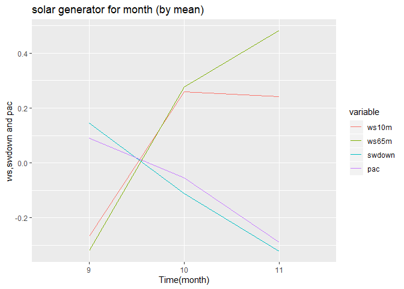

```r
mytheme <- theme_grey(base_family="STKaiti")
ggplot(data = DF_month, mapping = aes(x = month, y = value, color = variable, group = variable)) + geom_line()  + mytheme +  labs(x = "Time(month)") + labs(y = "ws,swdown and pac")+ ggtitle("solar generator for month (by mean)")
```

### 3.2 Solar data visulation for different location

Three month of the PAC data were draw by different locations. As the picture showed below, the red line (chungwa) were higher than other locations and the xinglongmarket was the lowest.

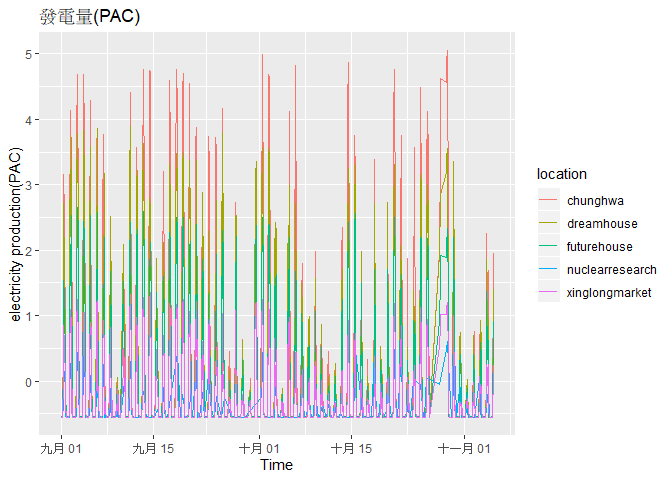

```r
pac_graph <- ggplot(cbso_z, aes(x=mytime, y=pac, colour = location, group = location)) + geom_line() + ggtitle("發電量(PAC)")+  labs(x = "Time")+ labs(y = "electricity production(PAC)")
pac_graph
```

Different location of the generators

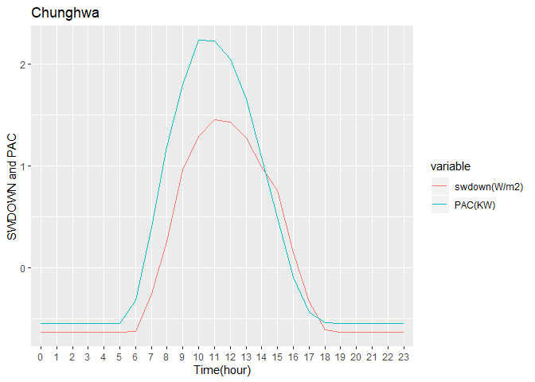

```r
chunghwa <- filter(cbso_z, cbso_z$location=="chunghwa")
chunghwa_graph <- chunghwa[,c(1,5,6)]
lchunghwa <- melt(chunghwa_graph,id.vars = "mytime",measure.vars = colnames(chunghwa_graph[-1]))
lchunghwa$hour <- factor(hour(lchunghwa$mytime))
DF_chunghwa <- aggregate(value ~ hour*variable, data = lchunghwa, FUN = mean)
mytheme <- theme_grey(base_family="STKaiti")
graph_chunghwa <- ggplot(data = DF_chunghwa, mapping = aes(x = hour, y = value, color = variable, group = variable)) + geom_line()  + mytheme  + labs(x = "Time(hour)") + labs(y = "SWDOWN and PAC")+ ggtitle("Chunghwa") + scale_color_discrete(labels=c("swdown(W/m2)","PAC(KW)"))
graph_chunghwa
```

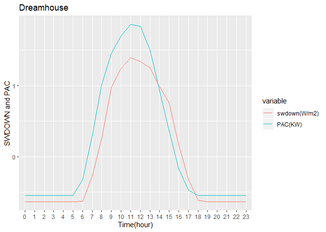

```r
dreamhouse <- filter(cbso_z, cbso_z$location=="dreamhouse")
dreamhouse_graph <- dreamhouse[,c(1,5,6)]
ldreamhouse <- melt(dreamhouse_graph,id.vars = "mytime",measure.vars = colnames(chunghwa_graph[-1]))
ldreamhouse$hour <- factor(hour(ldreamhouse$mytime))
DF_dreamhouse <- aggregate(value ~ hour*variable, data = ldreamhouse, FUN = mean)
graph_dreamhouse <- ggplot(data = DF_dreamhouse, mapping = aes(x = hour, y = value, color = variable, group = variable)) + geom_line()  + mytheme+ labs(x = "Time(hour)") + labs(y = "SWDOWN and PAC")+ ggtitle("Dreamhouse")+ scale_color_discrete(labels=c("swdown(W/m2)","PAC(KW)"))
graph_dreamhouse
```

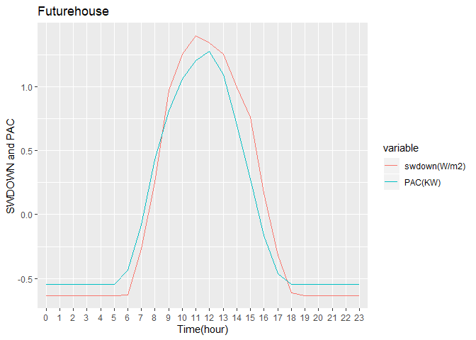

```r
futurehouse <- filter(cbso_z, cbso_z$location=="futurehouse")
futurehouse_graph <- futurehouse[,c(1,5,6)]
lfuturehouse <- melt(futurehouse_graph,id.vars = "mytime",measure.vars = colnames(futurehouse_graph[-1]))
lfuturehouse$hour <- factor(hour(lfuturehouse$mytime))
DF_futurehouse <- aggregate(value ~ hour*variable, data = lfuturehouse, FUN = mean)
graph_futurehouse <- ggplot(data = DF_futurehouse, mapping = aes(x = hour, y = value, color = variable, group = variable)) + geom_line()  + mytheme + labs(x = "Time(hour)") + labs(y = "SWDOWN and PAC")+ ggtitle("Futurehouse")+ scale_color_discrete(labels=c("swdown(W/m2)","PAC(KW)"))
graph_futurehouse
```

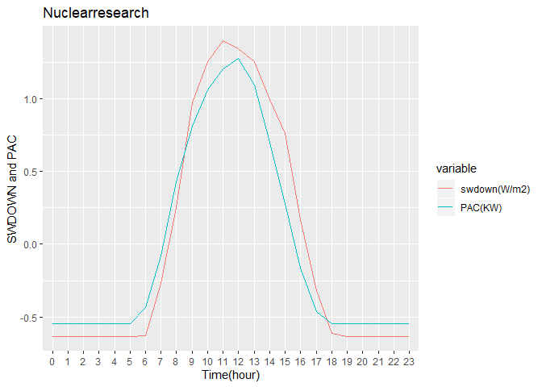

```r
nuclearresearch <- filter(cbso_z, cbso_z$location=="nuclearresearch")
nuclearresearch_graph <- futurehouse[,c(1,5,6)]
lnuclearresearch <- melt(nuclearresearch_graph,id.vars = "mytime",measure.vars = colnames(nuclearresearch_graph[-1]))
lnuclearresearch$hour <- factor(hour(lnuclearresearch$mytime))
DF_nuclearresearch <- aggregate(value ~ hour*variable, data = lnuclearresearch, FUN = mean)
graph_nuclearresearch <- ggplot(data = DF_nuclearresearch, mapping = aes(x = hour, y = value, color = variable, group = variable)) + geom_line()  + mytheme  + labs(x = "Time(hour)") + labs(y = "SWDOWN and PAC")+ ggtitle("Nuclearresearch")+ scale_color_discrete(labels=c("swdown(W/m2)","PAC(KW)"))
graph_nuclearresearch
```

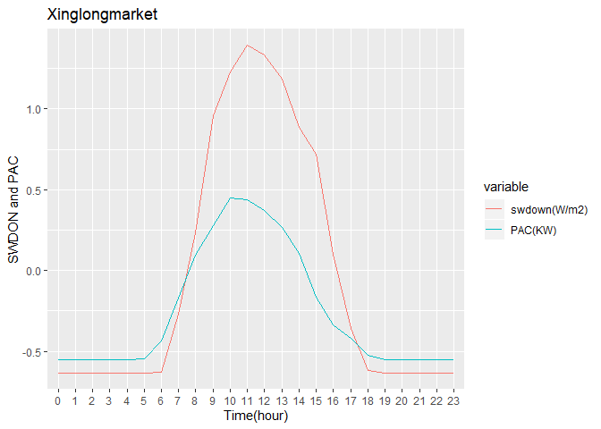

```r
xinglongmarket <- filter(cbso_z, cbso_z$location=="xinglongmarket")
xinglongmarket_graph <-  xinglongmarket[,c(1,5,6)]
lxinglongmarket <- melt(xinglongmarket_graph,id.vars = "mytime",measure.vars = colnames(xinglongmarket_graph[-1]))
lxinglongmarket$hour <- factor(hour(lxinglongmarket$mytime))
DF_xinglongmarket <- aggregate(value ~ hour*variable, data = lxinglongmarket, FUN = mean)
graph_xinglongmarket <- ggplot(data = DF_xinglongmarket, mapping = aes(x = hour, y = value, color = variable, group = variable)) + geom_line()  + mytheme  + labs(x = "Time(hour)") + labs(y = "SWDON and PAC")+ ggtitle("Xinglongmarket")+ scale_color_discrete(labels=c("swdown(W/m2)","PAC(KW)"))
graph_xinglongmarket
```

### 3.3 Correlation between PAC and SWDOWN (ex. Chunghwa)

```r
chunghwa_cor <- chunghwa[,-c(1:2)]
head(nearZeroVar(chunghwa_cor,saveMetrics = TRUE))
```

```
##         freqRatio percentUnique zeroVar   nzv
## ws10m    1.666667      84.32288   FALSE FALSE
## ws65m    1.333333      88.59239   FALSE FALSE
## swdown 772.000000      48.56571   FALSE FALSE
## pac    353.500000      52.70180   FALSE FALSE
```

```r
names(chunghwa_cor)[nearZeroVar(chunghwa_cor,saveMetrics = TRUE)$zeroVar]
```

```
## character(0)
```

```r
correlations <- cor(chunghwa_cor)
dim(correlations)
```

```
## [1] 4 4
```

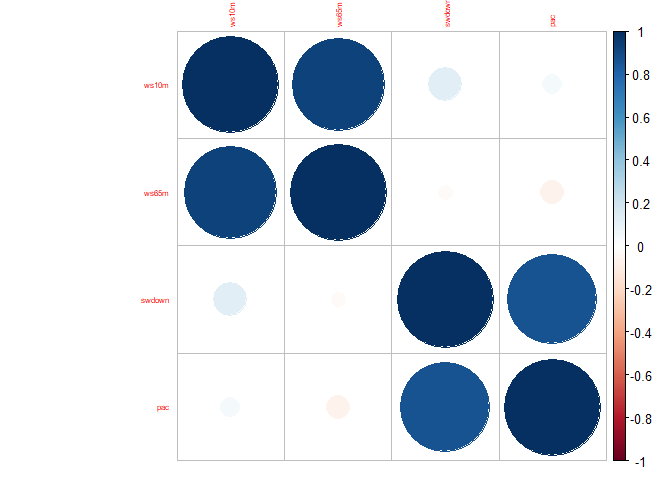

```r
corrplot(correlations,order = "hclust",tl.cex = 0.5)
```

# 4. Data preparation for wind driven generator

```r
formosa <- read.csv("C:/Users/Christine Liou/Documents/ETC/Data_1105/17.csv")
formosa$location <- "formosa"
chengloong <- read.csv("C:/Users/Christine Liou/Documents/ETC/Data_1105/47.csv")
chengloong$location <- "chengloong"
cbwd <- rbind(formosa,chengloong)
rm(formosa,chengloong)

names(cbwd)
```

```
##  [1] "SESSIONS"      "RANK"          "MYTIME"        "MYHOUR"
##  [5] "INITIAL_DATE"  "FCST"          "STNNO"         "FCST_DATETIME"
##  [9] "WS10M"         "WS65M"         "SWDOWN"        "USER_ID"
## [13] "INITIAL_TIME"  "EQUIPMENT_ID"  "T2"            "SHUM2"
## [17] "RAIN"          "PAC"           "VAC"           "IAC"
## [21] "EAC"           "location"
```

```r
names(cbwd)[c(1:2,4:8,12:17)]
```

```
##  [1] "SESSIONS"      "RANK"          "MYHOUR"        "INITIAL_DATE"
##  [5] "FCST"          "STNNO"         "FCST_DATETIME" "USER_ID"
##  [9] "INITIAL_TIME"  "EQUIPMENT_ID"  "T2"            "SHUM2"
## [13] "RAIN"
```

```r
cbwd <- cbwd[,-c(1:2,4:8,12:17)]
summary(cbwd)
```

```
##            MYTIME         WS10M              WS65M
##  2018/09/01 00:   2   Min.   :   0.100   Min.   :-999.000
##  2018/09/01 01:   2   1st Qu.:   3.224   1st Qu.:   4.154
##  2018/09/01 02:   2   Median :   5.812   Median :   7.521
##  2018/09/01 03:   2   Mean   :  10.373   Mean   :   5.402
##  2018/09/01 04:   2   3rd Qu.:   9.250   3rd Qu.:  11.321
##  2018/09/01 05:   2   Max.   :1412.799   Max.   :  22.980
##  (Other)      :2982
##      SWDOWN            PAC               VAC             IAC
##  Min.   :-999.0   Min.   : -19048   Min.   :11097   Min.   :  0.21
##  1st Qu.:   0.0   1st Qu.: -10296   1st Qu.:11243   1st Qu.:  0.87
##  Median :   0.0   Median : 316522   Median :11412   Median : 16.11
##  Mean   : 235.2   Mean   : 671181   Mean   :11389   Mean   : 35.23
##  3rd Qu.: 501.4   3rd Qu.:1281052   3rd Qu.:11529   3rd Qu.: 65.36
##  Max.   : 980.4   Max.   :2605056   Max.   :11663   Max.   :138.45
##
##       EAC            location
##  Min.   :3374057   Length:2994
##  1st Qu.:3608466   Class :character
##  Median :4101334   Mode  :character
##  Mean   :4975430
##  3rd Qu.:6265252
##  Max.   :7189438
##
```

```r
date <- substr(cbwd$MYTIME, 1,10)
time <- paste(substr(cbwd$MYTIME,12, 13),":00:00",sep = "")
cbwd$MYTIME <- as.POSIXct(paste(date,time, sep = " "))

cbwd$location <- factor(cbwd$location)

table(cbwd$WS65M=="-999")
```

```
##
## FALSE  TRUE
##  2986     8
```

```r
table(cbwd$PAC< 0 )
```

```
##
## FALSE  TRUE
##  2075   919
```

```r
cbwd <- subset(cbwd,WS65M!="-999")
cbwd <- subset(cbwd,PAC>0)
summary(cbwd)
```

```
##      MYTIME                        WS10M            WS65M
##  Min.   :2018-09-01 12:00:00   Min.   : 0.289   Min.   : 0.760
##  1st Qu.:2018-09-26 06:00:00   1st Qu.: 4.930   1st Qu.: 6.820
##  Median :2018-10-08 10:00:00   Median : 7.569   Median : 9.683
##  Mean   :2018-10-07 14:00:47   Mean   : 8.235   Mean   :10.056
##  3rd Qu.:2018-10-20 18:00:00   3rd Qu.:10.705   3rd Qu.:12.695
##  Max.   :2018-11-05 10:00:00   Max.   :20.998   Max.   :22.980
##      SWDOWN            PAC                 VAC             IAC
##  Min.   :  0.00   Min.   :    109.9   Min.   :11097   Min.   :  0.21
##  1st Qu.:  0.00   1st Qu.: 265608.5   1st Qu.:11242   1st Qu.: 13.69
##  Median : 20.05   Median : 828466.1   Median :11417   Median : 42.30
##  Mean   :262.28   Mean   : 975241.7   Mean   :11388   Mean   : 50.55
##  3rd Qu.:561.47   3rd Qu.:1624053.6   3rd Qu.:11530   3rd Qu.: 82.77
##  Max.   :980.44   Max.   :2605055.7   Max.   :11652   Max.   :138.45
##       EAC                location
##  Min.   :3374100   chengloong:1045
##  1st Qu.:3652177   formosa   :1022
##  Median :4100099
##  Mean   :5046608
##  3rd Qu.:6473596
##  Max.   :7189438
```

```r
cbwd_sc <- as.data.frame(scale(cbwd[,c(2:5)]))
cbwd_scframe <- cbind(cbwd$MYTIME,cbwd$location,cbwd_sc)
colnames(cbwd_scframe) <- c("mytime","location","ws10m","ws65m","swdown","pac")
summary(cbwd_scframe)
```

```
##      mytime                          location        ws10m
##  Min.   :2018-09-01 12:00:00   chengloong:1045   Min.   :-1.9297
##  1st Qu.:2018-09-26 06:00:00   formosa   :1022   1st Qu.:-0.8026
##  Median :2018-10-08 10:00:00                     Median :-0.1617
##  Mean   :2018-10-07 14:00:47                     Mean   : 0.0000
##  3rd Qu.:2018-10-20 18:00:00                     3rd Qu.: 0.5999
##  Max.   :2018-11-05 10:00:00                     Max.   : 3.0996
##      ws65m              swdown             pac
##  Min.   :-2.20263   Min.   :-0.7929   Min.   :-1.2697
##  1st Qu.:-0.76681   1st Qu.:-0.7929   1st Qu.:-0.9240
##  Median :-0.08848   Median :-0.7323   Median :-0.1911
##  Mean   : 0.00000   Mean   : 0.0000   Mean   : 0.0000
##  3rd Qu.: 0.62528   3rd Qu.: 0.9045   3rd Qu.: 0.8448
##  Max.   : 3.06202   Max.   : 2.1712   Max.   : 2.1222
```

```r
cbwd_sc_noloc <- cbwd_scframe[,-2]
```

# 5. Deep learning for LSTM

### 5.1 Solar data

The model was built from solar generator data observed from Chunghwa.

```r
library(keras)
library(dplyr)
library(ggplot2)
library(ggthemes)
library(lubridate)
library(xts)
set.seed(7)

dataframe <- read.csv(
  'C:/Users/Christine Liou/Documents/ETC/Data_1105/14.csv')

date <- substr(dataframe$MYTIME, 1,10)
time <- paste(substr(dataframe$MYTIME,12, 13),":00:00",sep = "")
dataframe$MYTIME <- as.POSIXct(paste(date,time, sep = " "))


dataframe <- dataframe[order(dataframe$MYTIME),]
```

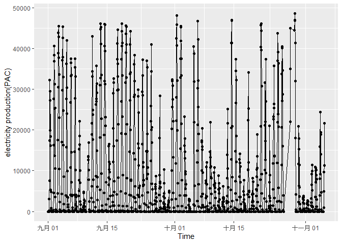

```r
ggplot(
  data = dataframe,
  mapping = aes(
    x = MYTIME,
    y = PAC)) +
  geom_line() +
  geom_point() +
  labs(x = "Time") +
  labs(y = "electricity production(PAC)")
```

Data in September from Chunghwa

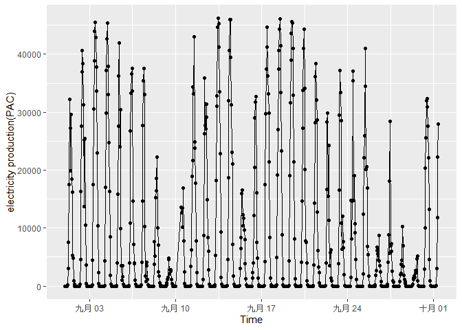

```r
sept <- dataframe[1:720,]

ggplot(
  data = sept,
  mapping = aes(
    x = MYTIME,
    y = PAC)) +
  geom_line() +
  geom_point() +
  labs(x = "Time") +
  labs(y = "electricity production(PAC)")
```

```r
names(sept)
```

```
##  [1] "SESSIONS"      "RANK"          "MYTIME"        "MYHOUR"
##  [5] "INITIAL_DATE"  "FCST"          "STNNO"         "FCST_DATETIME"
##  [9] "WS10M"         "WS65M"         "SWDOWN"        "USER_ID"
## [13] "INITIAL_TIME"  "EQUIPMENT_ID"  "T2"            "SHUM2"
## [17] "RAIN"          "PAC"           "VAC"           "IAC"
## [21] "EAC"
```

```r
sept <- sept[,c(3,18)]
```

Data normalization

```r
max_value <- max(sept$PAC)
min_value <- min(sept$PAC)
spread <- max_value - min_value

dataset <- (sept$PAC - min_value) / spread #正規化資料
range(dataset)
```

```
## [1] 0 1
```

Build the model

```r
create_dataset <- function(dataset,
                           look_back = 1)
{
  l <- length(dataset)
  dataX <- array(dim = c(l - look_back, look_back))

  for (i in 1:ncol(dataX))
  {
    dataX[, i] <- dataset[i:(l - look_back + i - 1)]
  }

  dataY <- array(
    data = dataset[(look_back + 1):l],
    dim = c(l - look_back, 1))

  return(
    list(
      dataX = dataX,
      dataY = dataY))
} #設定x y 的資料格式

train_size <- as.integer(length(dataset) * 0.67)
test_size <- length(dataset) - train_size

train <- dataset[1:train_size]
test <- dataset[(train_size + 1):length(dataset)]

cat(length(train), length(test))  #切分訓練集與測試集
```

```
## 482 238
```

```r
# 482 238

look_back <- 1           #設定t-1
trainXY <- create_dataset(train, look_back)
testXY <-  create_dataset(test, look_back)

dim_train <- dim(trainXY$dataX)
dim_test <- dim(testXY$dataX)

# reshape input to be [samples, time steps, features]
dim(trainXY$dataX) <- c(dim_train[1], 1, dim_train[2])
dim(testXY$dataX) <- c(dim_test[1], 1, dim_test[2])
```

Training data

```r
library(keras)
library(tensorflow)
model <- keras_model_sequential()

model %>%
  layer_lstm(
    units = 4,
    input_shape = c(1, look_back)) %>%
  layer_dense(
    units = 1) %>%
  compile(
    loss = 'mean_squared_error',
    optimizer = 'adam') %>%
  fit(trainXY$dataX,
      trainXY$dataY,
      epochs = 30,  #調30代就差不多
      batch_size = 1,
      verbose = 2)
```

Result

```r
trainScore <- model %>%
  evaluate(
    trainXY$dataX,
    trainXY$dataY,
    verbose = 2)

testScore <- model %>%
  evaluate(
    testXY$dataX,
    testXY$dataY,
    verbose = 2)

# trainScore_inv = trainScore * spread + min_value

sprintf(
  'Train Score: %.4f MSE (%.4f RMSE)',
  trainScore * spread^2,
  sqrt(trainScore) * spread)
```

```
## [1] "Train Score: 31089840.4522 MSE (5575.8264 RMSE)"
```

```r
sprintf(
  'Test Score: %.4f MSE (%.4f RMSE)',
  testScore * spread^2,
  sqrt(testScore) * spread)
```

```
## [1] "Test Score: 23055459.2870 MSE (4801.6101 RMSE)"
```

Visulation of the result

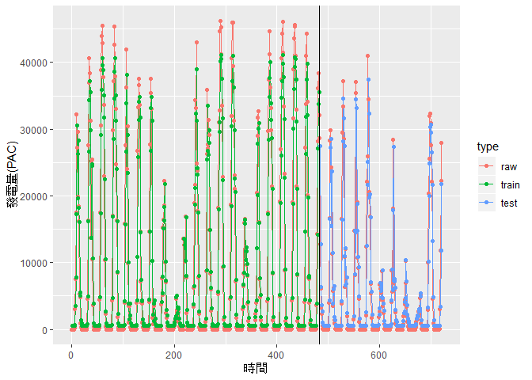

```r
trainPredict <- model %>%
  predict(
    trainXY$dataX,
    verbose = 2)
testPredict <- model %>%
  predict(
    testXY$dataX,
    verbose = 2)

trainPredict <- trainPredict * spread + min_value
testPredict <- testPredict * spread + min_value

df <- data.frame(
  index = 1:length(dataset),
  value = dataset * spread + min_value,
  type = 'raw') %>%
  rbind(
    data.frame(
      index = 1:length(trainPredict) + look_back,
      value = trainPredict,
      type = 'train')) %>%
  rbind(
    data.frame(
      index = 1:length(testPredict) + look_back + length(train),
      value = testPredict,
      type = 'test'))

ggplot(data = df) +
  geom_line(
    mapping = aes(
      x = index,
      y = value,
      color = type)) +
  geom_point(
    mapping = aes(
      x = index,
      y = value,
      color = type)) +
  geom_vline(
    xintercept = length(train) + 0.5) +
  labs(x = "時間") +
  labs(y = "發電量(PAC)")
```

```r
mean((trainPredict - mean(trainPredict))^2)
```

```
## [1] 164949889
```

```r
sqrt(mean((trainPredict - mean(trainPredict))^2))
```

```
## [1] 12843.28
```

```r
trainActual = trainXY$dataY * spread + min_value
mean(trainActual)
```

```
## [1] 9608.909
```

```r
sd(trainActual)
```

```
## [1] 14108.3
```

```r
#summary(trainActual)
#summary(trainPredict)
```

```r
cor(trainActual, trainPredict)
```

```
##           [,1]
## [1,] 0.9185843
```

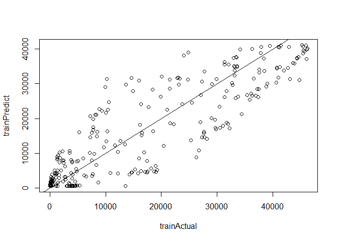

```r
plot(trainActual, trainPredict)
abline(a = 0, b = 1)
```

```r
testActual = testXY$dataY * spread + min_value
mean(testActual)
```

```
## [1] 5210.124
```

```r
sd(testActual)
```

```
## [1] 9215.629
```

```r
#summary(testActual)
#summary(testPredict)

cor(testActual, testPredict)
```

```
##           [,1]
## [1,] 0.8570221
```

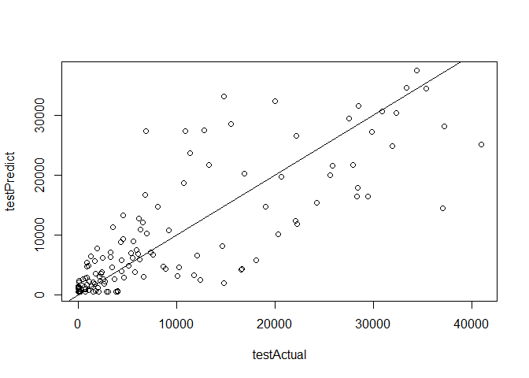

```r
plot(testActual, testPredict)
abline(a = 0, b = 1)
```

Total Chunghwa data

```r
max_value <- max(dataframe$PAC)
min_value <- min(dataframe$PAC)
spread <- max_value - min_value

dataset <- (dataframe$PAC - min_value) / spread #正規化資料
range(dataset)
```

```
## [1] 0 1
```

```r
create_dataset <- function(dataset,
                           look_back = 1)
{
  l <- length(dataset)
  dataX <- array(dim = c(l - look_back, look_back))

  for (i in 1:ncol(dataX))
  {
    dataX[, i] <- dataset[i:(l - look_back + i - 1)]
  }

  dataY <- array(
    data = dataset[(look_back + 1):l],
    dim = c(l - look_back, 1))

  return(
    list(
      dataX = dataX,
      dataY = dataY))
} #設定x y 的資料格式

train_size <- as.integer(length(dataset) * 0.67)
test_size <- length(dataset) - train_size

train <- dataset[1:train_size]
test <- dataset[(train_size + 1):length(dataset)]

cat(length(train), length(test))  #切分訓練集與測試集
```

```
## 1007 496
```

```r
#1007 496
```

```r
for (i in c(1:5)){
  look_back <- i           #設定t-1
  trainXY <- create_dataset(train, look_back)
  testXY <-  create_dataset(test, look_back)

  dim_train <- dim(trainXY$dataX)
  dim_test <- dim(testXY$dataX)

  # reshape input to be [samples, time steps, features]
  dim(trainXY$dataX) <- c(dim_train[1], 1, dim_train[2])
  dim(testXY$dataX) <- c(dim_test[1], 1, dim_test[2])


  #建模訓練
  model <- keras_model_sequential()

  model %>%
    layer_lstm(
      units = 4,
      input_shape = c(1, look_back)) %>%
    layer_dense(
      units = 1) %>%
    compile(
      loss = 'mean_squared_error',
      optimizer = 'adam') %>%
    fit(trainXY$dataX,
        trainXY$dataY,
        epochs = 30,  #調30代就差不多
        batch_size = 1,
        verbose = 2)

  #訓練結果
  trainScore <- model %>%
    evaluate(
      trainXY$dataX,
      trainXY$dataY,
      verbose = 2)

  testScore <- model %>%
    evaluate(
      testXY$dataX,
      testXY$dataY,
      verbose = 2)

  # trainScore_inv = trainScore * spread + min_value

  train_RMSE <- sprintf(
    'Train Score: %.4f MSE (%.4f RMSE)',
    trainScore * spread^2,
    sqrt(trainScore) * spread)
  print(train_RMSE)


  test_RMSE <- sprintf(
    'Test Score: %.4f MSE (%.4f RMSE)',
    testScore * spread^2,
    sqrt(testScore) * spread)
  print(test_RMSE)


  #把訓練集的擬合值、測試及的預測值和原始數據畫在一起
  #灰線是真實數據，深藍色是訓練集的訓練結果，淺藍色是預測集的預測值
  trainPredict <- model %>%
    predict(
      trainXY$dataX,
      verbose = 2)
  testPredict <- model %>%
    predict(
      testXY$dataX,
      verbose = 2)

  trainPredict <- trainPredict * spread + min_value
  testPredict <- testPredict * spread + min_value

  df <- data.frame(
    index = 1:length(dataset),
    value = dataset * spread + min_value,
    type = 'raw') %>%
    rbind(
      data.frame(
        index = 1:length(trainPredict) + look_back,
        value = trainPredict,
        type = 'train')) %>%
    rbind(
      data.frame(
        index = 1:length(testPredict) + look_back + length(train),
        value = testPredict,
        type = 'test'))



  mean((trainPredict - mean(trainPredict))^2)
  sqrt(mean((trainPredict - mean(trainPredict))^2))

  trainActual = trainXY$dataY * spread + min_value
  mean(trainActual)
  sd(trainActual)

  train_cor <- cor(trainActual, trainPredict)
  print(train_cor)


  testActual = testXY$dataY * spread + min_value
  mean(testActual)
  sd(testActual)

  test_cor <- cor(testActual, testPredict)
  print(test_cor)

}
```

```
## [1] "Train Score: 27104849.6864 MSE (5206.2318 RMSE)"
## [1] "Test Score: 24669828.7099 MSE (4966.8731 RMSE)"
##           [,1]
## [1,] 0.9067595
##           [,1]
## [1,] 0.8937099
## [1] "Train Score: 22794125.3968 MSE (4774.3194 RMSE)"
## [1] "Test Score: 20704857.7737 MSE (4550.2591 RMSE)"
##           [,1]
## [1,] 0.9249797
##           [,1]
## [1,] 0.9135639
## [1] "Train Score: 19301444.9925 MSE (4393.3410 RMSE)"
## [1] "Test Score: 20062338.0480 MSE (4479.1001 RMSE)"
##           [,1]
## [1,] 0.9346221
##           [,1]
## [1,] 0.9139142
## [1] "Train Score: 17801252.6749 MSE (4219.1531 RMSE)"
## [1] "Test Score: 19918153.6312 MSE (4462.9759 RMSE)"
##           [,1]
## [1,] 0.9404279
##           [,1]
## [1,] 0.9157477
## [1] "Train Score: 17361260.9112 MSE (4166.6846 RMSE)"
## [1] "Test Score: 18957084.2056 MSE (4353.9734 RMSE)"
##           [,1]
## [1,] 0.9411513
##           [,1]
## [1,] 0.9185227
```

### 5.2 Wind data

We only use wind driven generator observed from Formosa.

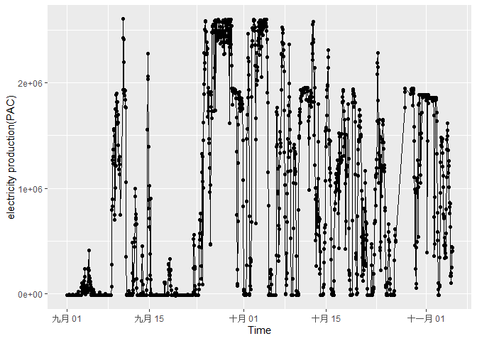

```r
dataframe <- read.csv(
  'C:/Users/Christine Liou/Documents/ETC/Data_1105/17.csv')

date <- substr(dataframe$MYTIME, 1,10)
time <- paste(substr(dataframe$MYTIME,12, 13),":00:00",sep = "")
dataframe$MYTIME <- as.POSIXct(paste(date,time, sep = " "))


dataframe <- dataframe[order(dataframe$MYTIME),]

ggplot(
  data = dataframe,
  mapping = aes(
    x = MYTIME,
    y = PAC)) +
  geom_line() +
  geom_point() +
  labs(x = "Time") +
  labs(y = "electricity production(PAC)")
```

Only select data in September

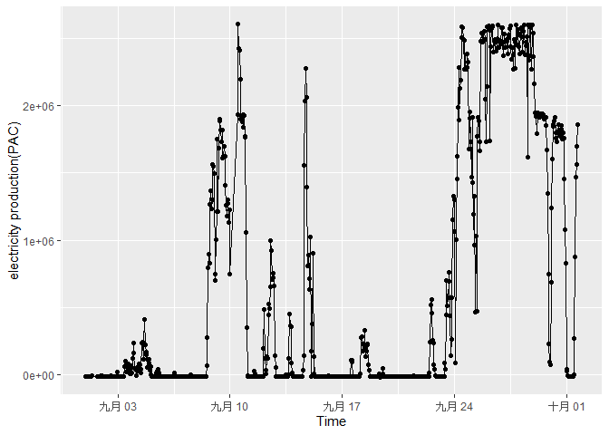

```r
sept <- dataframe[1:720,]

ggplot(
  data = sept,
  mapping = aes(
    x = MYTIME,
    y = PAC)) +
  geom_line() +
  geom_point() +
  labs(x = "Time") +
  labs(y = "electricity production(PAC)")
```

Normalization

```r
max_value <- max(sept$PAC)
min_value <- min(sept$PAC)
spread <- max_value - min_value

dataset <- (sept$PAC - min_value) / spread #正規化資料
range(dataset)
```

```
## [1] 0 1
```

Build the model

```r
create_dataset <- function(dataset,
                           look_back = 1)
{
  l <- length(dataset)
  dataX <- array(dim = c(l - look_back, look_back))

  for (i in 1:ncol(dataX))
  {
    dataX[, i] <- dataset[i:(l - look_back + i - 1)]
  }

  dataY <- array(
    data = dataset[(look_back + 1):l],
    dim = c(l - look_back, 1))

  return(
    list(
      dataX = dataX,
      dataY = dataY))
} #設定x y 的資料格式

train_size <- as.integer(length(dataset) * 0.67)
test_size <- length(dataset) - train_size

train <- dataset[1:train_size]
test <- dataset[(train_size + 1):length(dataset)]

cat(length(train), length(test))  #切分訓練集與測試集
```

```
## 482 238
```

```r
# 482 238

look_back <- 1           #設定t-1
trainXY <- create_dataset(train, look_back)
testXY <-  create_dataset(test, look_back)

dim_train <- dim(trainXY$dataX)
dim_test <- dim(testXY$dataX)

# reshape input to be [samples, time steps, features]
dim(trainXY$dataX) <- c(dim_train[1], 1, dim_train[2])
dim(testXY$dataX) <- c(dim_test[1], 1, dim_test[2])
```

Result

```r
model <- keras_model_sequential()

model %>%
  layer_lstm(
    units = 4,
    input_shape = c(1, look_back)) %>%
  layer_dense(
    units = 1) %>%
  compile(
    loss = 'mean_squared_error',
    optimizer = 'adam') %>%
  fit(trainXY$dataX,
      trainXY$dataY,
      epochs = 30,  #調30代就差不多
      batch_size = 1,
      verbose = 2)

#訓練結果
trainScore <- model %>%
  evaluate(
    trainXY$dataX,
    trainXY$dataY,
    verbose = 2)

testScore <- model %>%
  evaluate(
    testXY$dataX,
    testXY$dataY,
    verbose = 2)

# trainScore_inv = trainScore * spread + min_value

sprintf(
  'Train Score: %.4f MSE (%.4f RMSE)',
  trainScore * spread^2,
  sqrt(trainScore) * spread)
```

```
## [1] "Train Score: 26657716673.7589 MSE (163271.9102 RMSE)"
```

```r
sprintf(
  'Test Score: %.4f MSE (%.4f RMSE)',
  testScore * spread^2,
  sqrt(testScore) * spread)
```

```
## [1] "Test Score: 84064710277.6804 MSE (289939.1493 RMSE)"
```

Visulation of the result

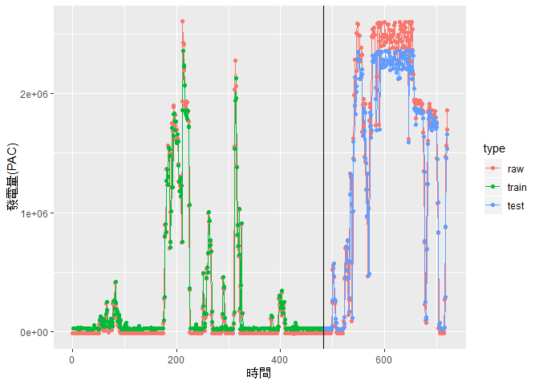

```r
trainPredict <- model %>%
  predict(
    trainXY$dataX,
    verbose = 2)
testPredict <- model %>%
  predict(
    testXY$dataX,
    verbose = 2)

trainPredict <- trainPredict * spread + min_value
testPredict <- testPredict * spread + min_value

df <- data.frame(
  index = 1:length(dataset),
  value = dataset * spread + min_value,
  type = 'raw') %>%
  rbind(
    data.frame(
      index = 1:length(trainPredict) + look_back,
      value = trainPredict,
      type = 'train')) %>%
  rbind(
    data.frame(
      index = 1:length(testPredict) + look_back + length(train),
      value = testPredict,
      type = 'test'))

ggplot(data = df) +
  geom_line(
    mapping = aes(
      x = index,
      y = value,
      color = type)) +
  geom_point(
    mapping = aes(
      x = index,
      y = value,
      color = type)) +
  geom_vline(
    xintercept = length(train) + 0.5) +
  labs(x = "時間") +
  labs(y = "發電量(PAC)")
```

```r
mean((trainPredict - mean(trainPredict))^2)
```

```
## [1] 242647735043
```

```r
sqrt(mean((trainPredict - mean(trainPredict))^2))
```

```
## [1] 492592.9
```

```r
trainActual = trainXY$dataY * spread + min_value
mean(trainActual)
```

```
## [1] 210391.1
```

```r
sd(trainActual)
```

```
## [1] 521377.3
```

```r
#summary(trainActual)
#summary(trainPredict)

cor(trainActual, trainPredict)
```

```
##           [,1]
## [1,] 0.9509221
```

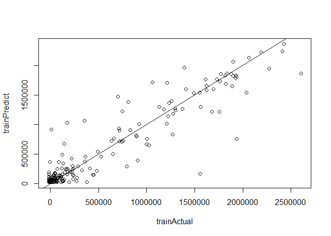

```r
plot(trainActual, trainPredict)
abline(a = 0, b = 1)
```

```r
testActual = testXY$dataY * spread + min_value
mean(testActual)
```

```
## [1] 1526237
```

```r
sd(testActual)
```

```
## [1] 979714.4
```

```r
#summary(testActual)
#summary(testPredict)

cor(testActual, testPredict)
```

```
##           [,1]
## [1,] 0.9608525
```

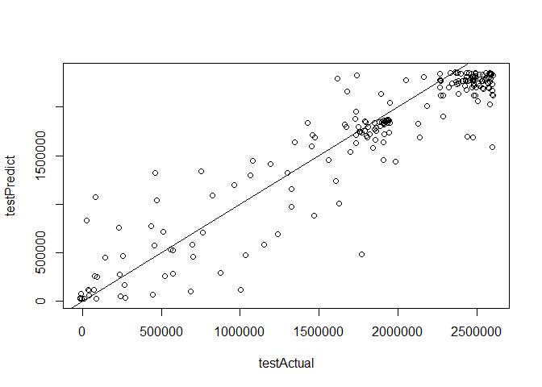

```r
plot(testActual, testPredict)
abline(a = 0, b = 1)
```

Total Formosa data

```r
max_value <- max(dataframe$PAC)
min_value <- min(dataframe$PAC)
spread <- max_value - min_value

dataset <- (dataframe$PAC - min_value) / spread #正規化資料
range(dataset)
```

```
## [1] 0 1
```

```r
create_dataset <- function(dataset,
                           look_back = 1)
{
  l <- length(dataset)
  dataX <- array(dim = c(l - look_back, look_back))

  for (i in 1:ncol(dataX))
  {
    dataX[, i] <- dataset[i:(l - look_back + i - 1)]
  }

  dataY <- array(
    data = dataset[(look_back + 1):l],
    dim = c(l - look_back, 1))

  return(
    list(
      dataX = dataX,
      dataY = dataY))
} #設定x y 的資料格式

train_size <- as.integer(length(dataset) * 0.67)
test_size <- length(dataset) - train_size

train <- dataset[1:train_size]
test <- dataset[(train_size + 1):length(dataset)]

cat(length(train), length(test))
```

```
## 1002 494
```

```r
for (i in c(1:5)){
  look_back <- i           #設定t-1
  trainXY <- create_dataset(train, look_back)
  testXY <-  create_dataset(test, look_back)

  dim_train <- dim(trainXY$dataX)
  dim_test <- dim(testXY$dataX)

  # reshape input to be [samples, time steps, features]
  dim(trainXY$dataX) <- c(dim_train[1], 1, dim_train[2])
  dim(testXY$dataX) <- c(dim_test[1], 1, dim_test[2])


  #建模訓練
  model <- keras_model_sequential()

  model %>%
    layer_lstm(
      units = 4,
      input_shape = c(1, look_back)) %>%
    layer_dense(
      units = 1) %>%
    compile(
      loss = 'mean_squared_error',
      optimizer = 'adam') %>%
    fit(trainXY$dataX,
        trainXY$dataY,
        epochs = 30,  #調30代就差不多
        batch_size = 1,
        verbose = 2)

  #訓練結果
  trainScore <- model %>%
    evaluate(
      trainXY$dataX,
      trainXY$dataY,
      verbose = 2)

  testScore <- model %>%
    evaluate(
      testXY$dataX,
      testXY$dataY,
      verbose = 2)

  # trainScore_inv = trainScore * spread + min_value

  train_RMSE <- sprintf(
    'Train Score: %.4f MSE (%.4f RMSE)',
    trainScore * spread^2,
    sqrt(trainScore) * spread)
  print(train_RMSE)


  test_RMSE <- sprintf(
    'Test Score: %.4f MSE (%.4f RMSE)',
    testScore * spread^2,
    sqrt(testScore) * spread)
  print(test_RMSE)


  #把訓練集的擬合值、測試及的預測值和原始數據畫在一起
  #灰線是真實數據，深藍色是訓練集的訓練結果，淺藍色是預測集的預測值
  trainPredict <- model %>%
    predict(
      trainXY$dataX,
      verbose = 2)
  testPredict <- model %>%
    predict(
      testXY$dataX,
      verbose = 2)

  trainPredict <- trainPredict * spread + min_value
  testPredict <- testPredict * spread + min_value

  df <- data.frame(
    index = 1:length(dataset),
    value = dataset * spread + min_value,
    type = 'raw') %>%
    rbind(
      data.frame(
        index = 1:length(trainPredict) + look_back,
        value = trainPredict,
        type = 'train')) %>%
    rbind(
      data.frame(
        index = 1:length(testPredict) + look_back + length(train),
        value = testPredict,
        type = 'test'))



  mean((trainPredict - mean(trainPredict))^2)
  sqrt(mean((trainPredict - mean(trainPredict))^2))

  trainActual = trainXY$dataY * spread + min_value
  mean(trainActual)
  sd(trainActual)

  train_cor <- cor(trainActual, trainPredict)
  print(train_cor)


  testActual = testXY$dataY * spread + min_value
  mean(testActual)
  sd(testActual)

  test_cor <- cor(testActual, testPredict)
  print(test_cor)

}
```

```
## [1] "Train Score: 54858972759.1227 MSE (234219.9239 RMSE)"
## [1] "Test Score: 74016328945.0364 MSE (272059.4217 RMSE)"
##          [,1]
## [1,] 0.972582
##           [,1]
## [1,] 0.9277964
## [1] "Train Score: 54282658224.3956 MSE (232986.3906 RMSE)"
## [1] "Test Score: 69209801622.9503 MSE (263077.5582 RMSE)"
##           [,1]
## [1,] 0.9730857
##           [,1]
## [1,] 0.9300894
## [1] "Train Score: 55074673825.4277 MSE (234679.9391 RMSE)"
## [1] "Test Score: 76146498960.0570 MSE (275946.5509 RMSE)"
##         [,1]
## [1,] 0.97295
##           [,1]
## [1,] 0.9284751
## [1] "Train Score: 53372821205.9070 MSE (231025.5856 RMSE)"
## [1] "Test Score: 70963276059.6677 MSE (266389.3317 RMSE)"
##           [,1]
## [1,] 0.9735146
##           [,1]
## [1,] 0.9288007
## [1] "Train Score: 54572309829.7806 MSE (233607.1699 RMSE)"
## [1] "Test Score: 69556492044.3979 MSE (263735.6480 RMSE)"
##           [,1]
## [1,] 0.9731761
##           [,1]
## [1,] 0.9300705
```